`Load the libraries`

```r
library(caret)
library(pander)
library(dplyr)
```

```r
data("GermanCredit")
```

# • Build a regression model to predict variable “Amount” as a function of other variables used following methodology:

1. Split sample randomly into training-test using a 632:368 ratio.
2. Build the model using the 63.2% training data and compute R-square in holdout data. (function lm() gives R-squares)
3. Save the coefficients, R-square in training and holdout samples. (To compute R-square in Holdout, take the square of correlation between actual and predicted values)

We’ll first select best predictor variables based on step-wise regressions

```r
# fit a model
fit <- lm(Amount~., data = GermanCredit)
# fit stepwise model
step_fit <- step(fit, trace = 0)
summary(step_fit)
```

```
##
## Call:
## lm(formula = Amount ~ Duration + InstallmentRatePercentage +
##     Telephone + Class + CheckingAccountStatus.lt.0 + CheckingAccountStatus.gt.200 +
##     CreditHistory.NoCredit.AllPaid + Purpose.NewCar + Purpose.UsedCar +
##     Purpose.Furniture.Equipment + Purpose.Radio.Television +
##     Purpose.DomesticAppliance + Purpose.Repairs + Purpose.Education +
##     Purpose.Retraining + Purpose.Business + SavingsAccountBonds.lt.100 +
##     SavingsAccountBonds.100.to.500 + SavingsAccountBonds.500.to.1000 +
##     EmploymentDuration.gt.7 + Personal.Male.Single + OtherDebtorsGuarantors.CoApplicant +
##     Property.RealEstate + Property.Insurance + Property.CarOther +
##     Job.UnemployedUnskilled + Job.UnskilledResident + Job.SkilledEmployee,
##     data = GermanCredit)
##
## Residuals:
##     Min      1Q  Median      3Q     Max
## -5254.8 -1048.2  -125.2   672.9 10961.9
##
## Coefficients:
##                                     Estimate Std. Error t value Pr(>|t|)
## (Intercept)                         7026.770    623.306  11.273  < 2e-16
## Duration                             125.208      5.336  23.464  < 2e-16
## InstallmentRatePercentage           -802.738     53.473 -15.012  < 2e-16
## Telephone                           -499.824    130.916  -3.818 0.000143
## ClassGood                           -353.331    138.654  -2.548 0.010978
## CheckingAccountStatus.lt.0          -285.175    140.483  -2.030 0.042633
## CheckingAccountStatus.gt.200        -672.257    240.038  -2.801 0.005202
## CreditHistory.NoCredit.AllPaid       829.486    302.837   2.739 0.006275
## Purpose.NewCar                     -1741.606    553.753  -3.145 0.001711
## Purpose.UsedCar                    -1084.157    564.176  -1.922 0.054940
## Purpose.Furniture.Equipment        -1783.742    559.441  -3.188 0.001476
## Purpose.Radio.Television           -2032.631    555.494  -3.659 0.000267
## Purpose.DomesticAppliance          -2388.669    759.651  -3.144 0.001715
## Purpose.Repairs                    -1663.769    667.728  -2.492 0.012880
## Purpose.Education                  -1886.952    601.819  -3.135 0.001768
## Purpose.Retraining                 -2205.528    818.799  -2.694 0.007190
## Purpose.Business                   -1926.931    569.487  -3.384 0.000744
## SavingsAccountBonds.lt.100          -287.400    147.047  -1.954 0.050931
## SavingsAccountBonds.100.to.500      -517.519    218.107  -2.373 0.017849
## SavingsAccountBonds.500.to.1000     -623.151    258.442  -2.411 0.016086
```

[output cut: 30 more lines]

```
## EmploymentDuration.gt.7
## Personal.Male.Single               ***
## OtherDebtorsGuarantors.CoApplicant *
## Property.RealEstate                ***
## Property.Insurance                 *
## Property.CarOther                  *
## Job.UnemployedUnskilled            ***
## Job.UnskilledResident              ***
## Job.SkilledEmployee                ***
## ---
## Signif. codes:  0 '***' 0.001 '**' 0.01 '*' 0.05 '.' 0.1 ' ' 1
##
## Residual standard error: 1798 on 971 degrees of freedom
## Multiple R-squared:  0.6058, Adjusted R-squared:  0.5944
## F-statistic:  53.3 on 28 and 971 DF,  p-value: < 2.2e-16
```

Based on step-wise regression we’ve selected a final model with 60.58% accuracy with the following variables as predictor variable.

Duration,InstallmentRatePercentage, Telephone,Class,CheckingAccountStatus.lt.0,CheckingAccountStatus.gt.200, CreditHistory.NoCredit.AllPaid,Purpose.NewCar,Purpose.UsedCar, Purpose.Furniture.Equipment,Purpose.Radio.Television, Purpose.DomesticAppliance,Purpose.Repairs,Purpose.Education, Purpose.Retraining,Purpose.Business,SavingsAccountBonds.lt.100, SavingsAccountBonds.100.to.500,SavingsAccountBonds.500.to.1000, EmploymentDuration.gt.7,Personal.Male.Single,OtherDebtorsGuarantors.CoApplicant, Property.RealEstate,Property.Insurance,Property.CarOther, Job.UnemployedUnskilled,Job.UnskilledResident,Job.SkilledEmployee

Subset the data

```r
data <-  dplyr::select(GermanCredit,
    Amount,
    Duration,InstallmentRatePercentage,
    Telephone,Class,CheckingAccountStatus.lt.0,CheckingAccountStatus.gt.200,
    CreditHistory.NoCredit.AllPaid,Purpose.NewCar,Purpose.UsedCar,
    Purpose.Furniture.Equipment,Purpose.Radio.Television,
    Purpose.DomesticAppliance,Purpose.Repairs,Purpose.Education,
    Purpose.Retraining,Purpose.Business,SavingsAccountBonds.lt.100,
    SavingsAccountBonds.100.to.500,SavingsAccountBonds.500.to.1000,
    EmploymentDuration.gt.7,Personal.Male.Single,OtherDebtorsGuarantors.CoApplicant,
    Property.RealEstate,Property.Insurance,Property.CarOther,
    Job.UnemployedUnskilled,Job.UnskilledResident,Job.SkilledEmployee
  )
```

## 1. Split sample randomly into training-test using a 632:368 ratio.

```r
# shuffle the data first
data <- data[sample(nrow(data)),]
train <- sample(seq_len(nrow(data)), size = floor(0.632*nrow(data)))
# split the data set into train and test
train_data <- data[train,]
test_data <- data[-train,]
```

## 2. Build the model using the 63.2% training data and compute R-square in holdout data. (function lm() gives R-squares)

```r
fit <- lm(Amount~., data = train_data)
predicted <- predict(fit, test_data)
SSE <- sum((test_data$Amount- predicted) ^ 2)
SST <- sum((test_data$Amount - mean(test_data$Amount)) ^ 2)
r_sq_test <- 1 - (SSE/SST)
r_sq_test
```

```
## [1] 0.5180499
```

## 3. Save the coefficients, R-square in training and holdout samples. (To compute R-square in Holdout, take the square of correlation between actual and predicted values)

```r
# coefficients
fit$coefficients
```

```
##                        (Intercept)                           Duration
##                          5480.0967                           134.7988
##          InstallmentRatePercentage                          Telephone
##                          -759.3395                          -627.3677
##                          ClassGood         CheckingAccountStatus.lt.0
##                           121.8000                          -345.0074
##       CheckingAccountStatus.gt.200     CreditHistory.NoCredit.AllPaid
##                          -608.3405                          1772.4535
##                     Purpose.NewCar                    Purpose.UsedCar
##                         -1438.8192                         -1069.1873
##        Purpose.Furniture.Equipment           Purpose.Radio.Television
##                         -1282.6611                         -1770.6684
##          Purpose.DomesticAppliance                    Purpose.Repairs
##                         -2150.2830                          -985.2389
##                  Purpose.Education                 Purpose.Retraining
##                         -1163.7990                         -2291.2310
##                   Purpose.Business         SavingsAccountBonds.lt.100
##                         -1478.3051                          -146.2077
##     SavingsAccountBonds.100.to.500    SavingsAccountBonds.500.to.1000
##                          -277.2728                          -525.9846
##            EmploymentDuration.gt.7               Personal.Male.Single
##                          -305.2525                           451.0088
## OtherDebtorsGuarantors.CoApplicant                Property.RealEstate
##                           176.9248                          -532.8562
##                 Property.Insurance                  Property.CarOther
##                          -321.2319                          -320.0518
##            Job.UnemployedUnskilled              Job.UnskilledResident
##                         -1515.1331                          -699.9216
##                Job.SkilledEmployee
##                          -793.3901
```

```r
hold_out_r2 <- cor(predicted, test_data$Amount)^2
hold_out_r2
```

```
## [1] 0.5185665
```

# • Repeat steps 1-3 1000 times. Save all 1000 results.

```r
Result <- data.frame(
  matrix(ncol = 32, nrow = 1000)
)
colnames(Result) <- c(
  "Intercept",
  colnames(data[,-1]),
  "R_Train",
  "R_Test",
  "Percent_r_fall"

)

for(i in 1:1000){

train <- sample(seq_len(nrow(data)), size = floor(0.632*nrow(data)))
# split the data set into train and test
train_data <- data[train,]
test_data <- data[-train,]
fit <- lm(Amount~., data = train_data)
coefficients <- fit$coefficients
predicted <- predict(fit, test_data)
train_r2 <- summary(fit)$r.squared
# coefficients
fit$coefficients
hold_out_r2 <- cor(predicted, test_data$Amount)^2
hold_out_r2

R_fall <- (train_r2 - hold_out_r2)/train_r2
Result[i,] <-  c(coefficients, train_r2, hold_out_r2, R_fall)

}
head(Result)
```

|  | Intercept | Duration | InstallmentRatePercentage | Telephone | Class | CheckingAccountStatus.lt.0 | CheckingAccountStatus.gt.200 | CreditHistory.NoCredit.AllPaid | Purpose.NewCar | Purpose.UsedCar | Purpose.Furniture.Equipment | Purpose.Radio.Television | Purpose.DomesticAppliance | Purpose.Repairs | Purpose.Education | Purpose.Retraining | Purpose.Business | SavingsAccountBonds.lt.100 | SavingsAccountBonds.100.to.500 | SavingsAccountBonds.500.to.1000 | EmploymentDuration.gt.7 | Personal.Male.Single | OtherDebtorsGuarantors.CoApplicant | Property.RealEstate | Property.Insurance | Property.CarOther | Job.UnemployedUnskilled | Job.UnskilledResident | Job.SkilledEmployee | … |
| --- | --- | --- | --- | --- | --- | --- | --- | --- | --- | --- | --- | --- | --- | --- | --- | --- | --- | --- | --- | --- | --- | --- | --- | --- | --- | --- | --- | --- | --- | --- |
| 1 | 8086.224 | 123.1983 | -828.7289 | -478.1808 | -494.51887 | -273.87555 | -597.5211 | 741.2305 | -2457.756 | -1813.7281 | -2549.251 | -2793.851 | -3667.302 | -1616.1926 | -2592.055 | -3760.117 | -2720.257 | -301.0657 | -824.9643 | -684.8577 | -209.847751 | 393.4359 | 589.8027 | -661.0261 | -382.5224 | -375.9691 | -2705.889 | -1346.6271 | -1385.304 | … |
| 2 | 7582.858 | 127.2772 | -746.1385 | -318.4857 | -99.08982 | -284.48428 | -577.6927 | 1575.5863 | -3420.924 | -2295.8626 | -3226.461 | -3506.521 | -3596.819 | -3133.0767 | -3412.719 | -4348.799 | -3085.679 | -112.4562 | -437.6765 | -621.1460 | -99.783915 | 163.3021 | 715.5813 | -564.2708 | -236.9096 | -182.1884 | -2410.873 | -964.8389 | -1130.360 | … |
| 3 | 7395.808 | 117.0852 | -780.9282 | -514.3601 | -618.35398 | -552.15071 | -953.5133 | 1082.0644 | -1915.515 | -1302.1370 | -1931.208 | -2082.879 | -2414.345 | -1905.5848 | -1891.650 | -1807.882 | -1760.881 | -195.3379 | -375.6548 | -307.0528 | -134.619555 | 598.4875 | 869.5943 | -734.5970 | -430.1245 | -452.0409 | -1648.279 | -1365.9448 | -1435.564 | … |
| 4 | 6418.480 | 130.1847 | -802.0990 | -416.8732 | -303.59290 | -27.47502 | -755.6827 | 655.3095 | -1249.613 | -609.2400 | -1264.355 | -1386.974 | -2105.551 | -920.1434 | -1092.679 | -1561.712 | -1548.891 | -533.3806 | -349.9722 | -433.7514 | -481.665362 | 438.1064 | 619.5546 | -636.2824 | -393.5262 | -423.4074 | -1954.332 | -1267.4960 | -1265.229 | … |
| 5 | 7154.068 | 121.5651 | -743.5586 | -360.8772 | -238.85203 | -474.48607 | -647.7407 | 716.6049 | -1458.769 | -754.0483 | -1588.295 | -1888.928 | -2169.733 | -2245.3321 | -2185.243 | -2722.483 | -1901.391 | -213.5924 | -709.3454 | -631.2004 | 7.248093 | 343.0570 | 539.7118 | -672.6751 | -228.1951 | -261.4606 | -1932.179 | -1933.3495 | -1991.513 | … |
| 6 | 6251.442 | 123.8505 | -776.3333 | -422.1911 | -245.00835 | -367.08745 | -779.7379 | 1058.4561 | -1187.686 | -408.9200 | -1105.402 | -1498.420 | -1741.046 | -1537.2554 | -1118.934 | -1263.013 | -1443.927 | -292.8416 | -688.4269 | -877.9541 | -155.170324 | 515.2144 | 831.5883 | -576.6870 | -408.7310 | -270.9367 | -1902.089 | -1393.7387 | -1363.493 | … |

• Plot the distributions of all coefficients, holdout R2, and % fall in R2.

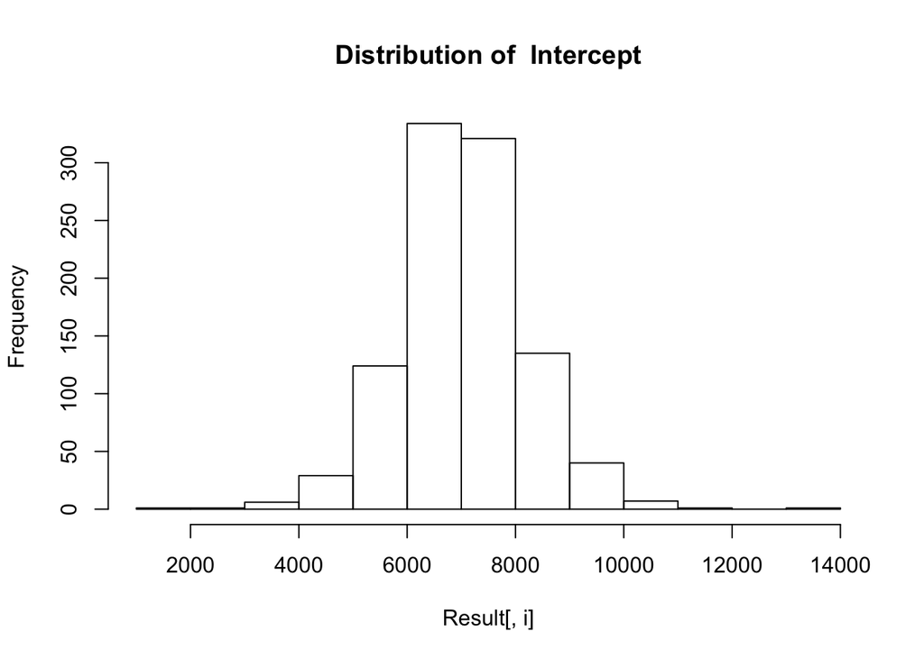

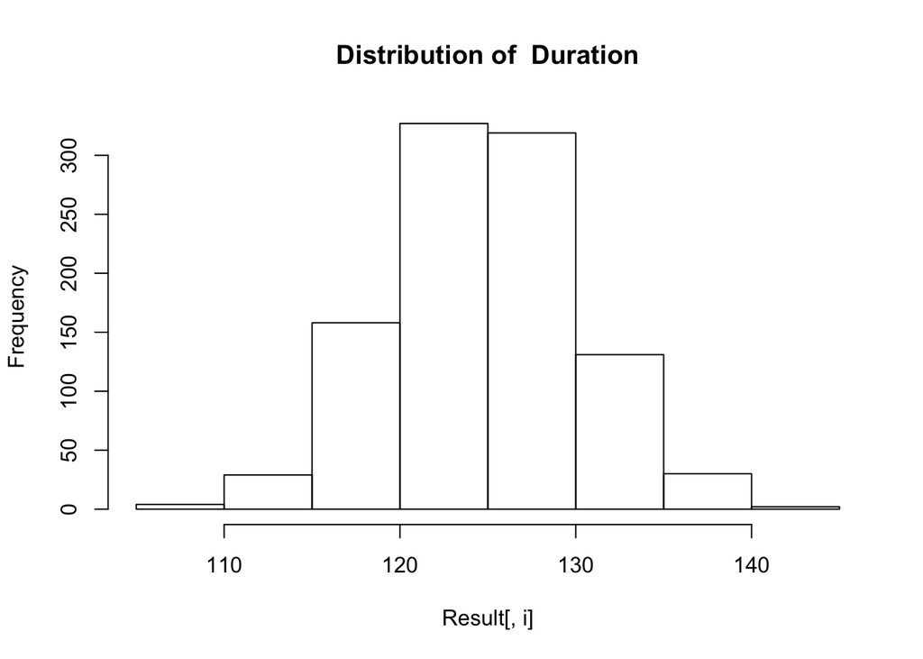

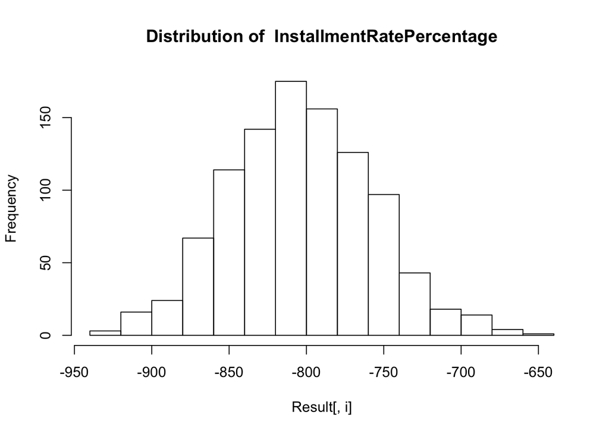

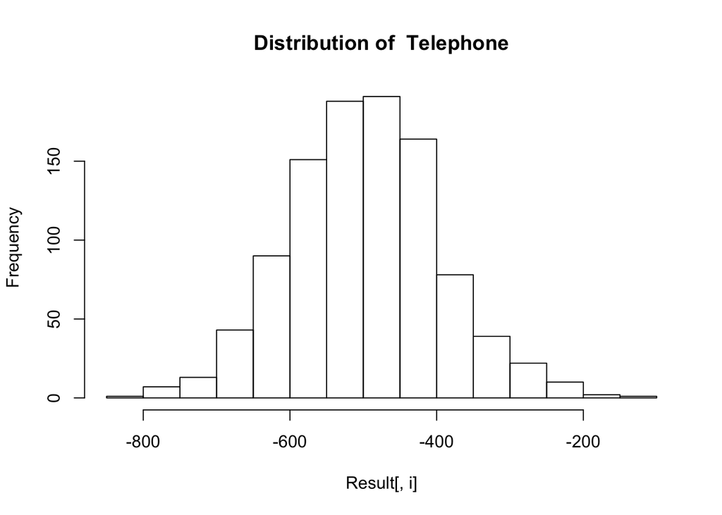

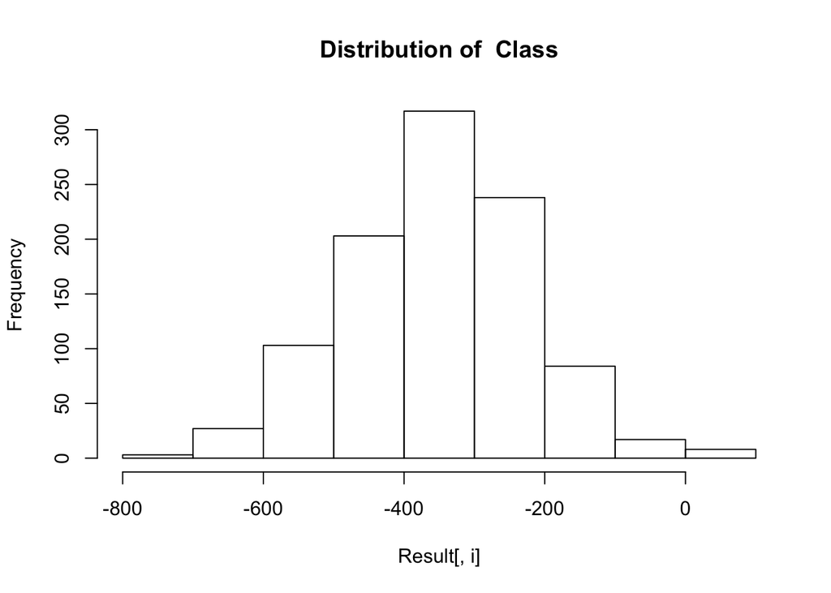

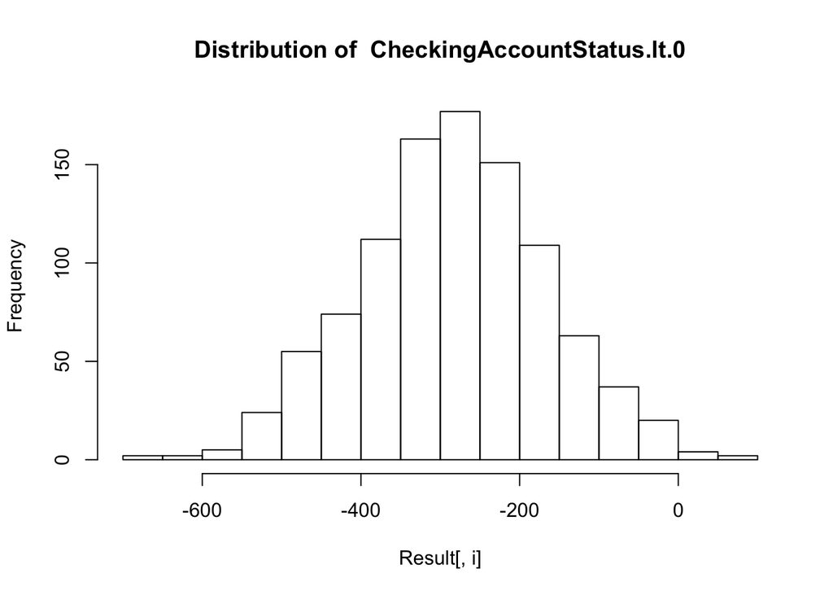

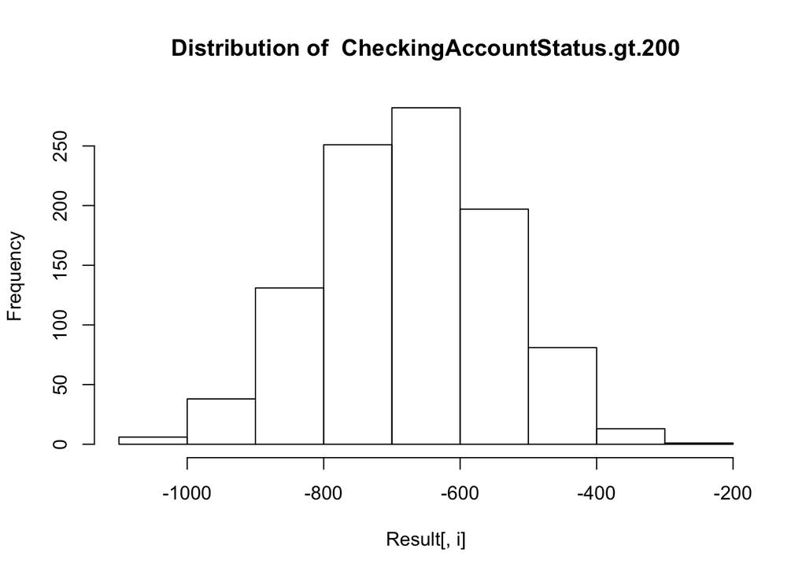

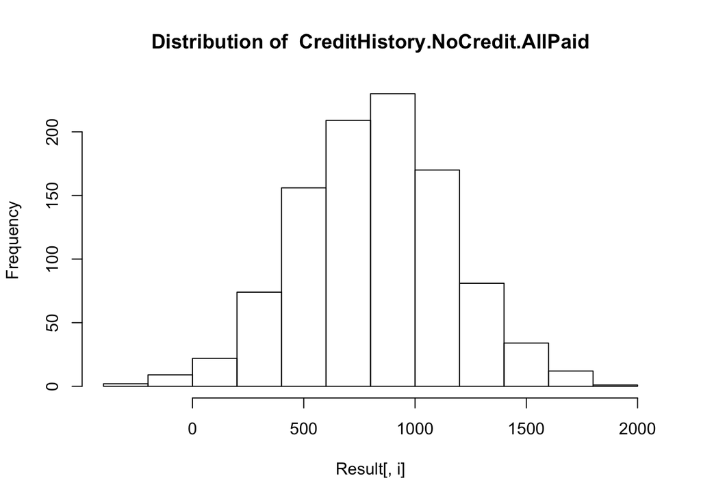

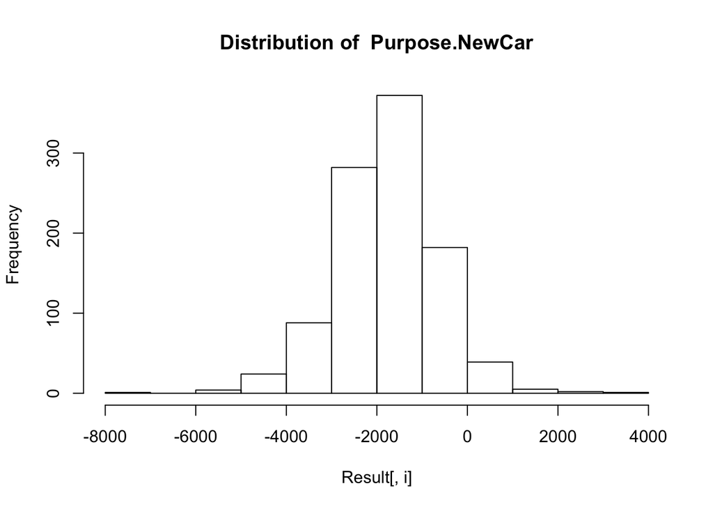

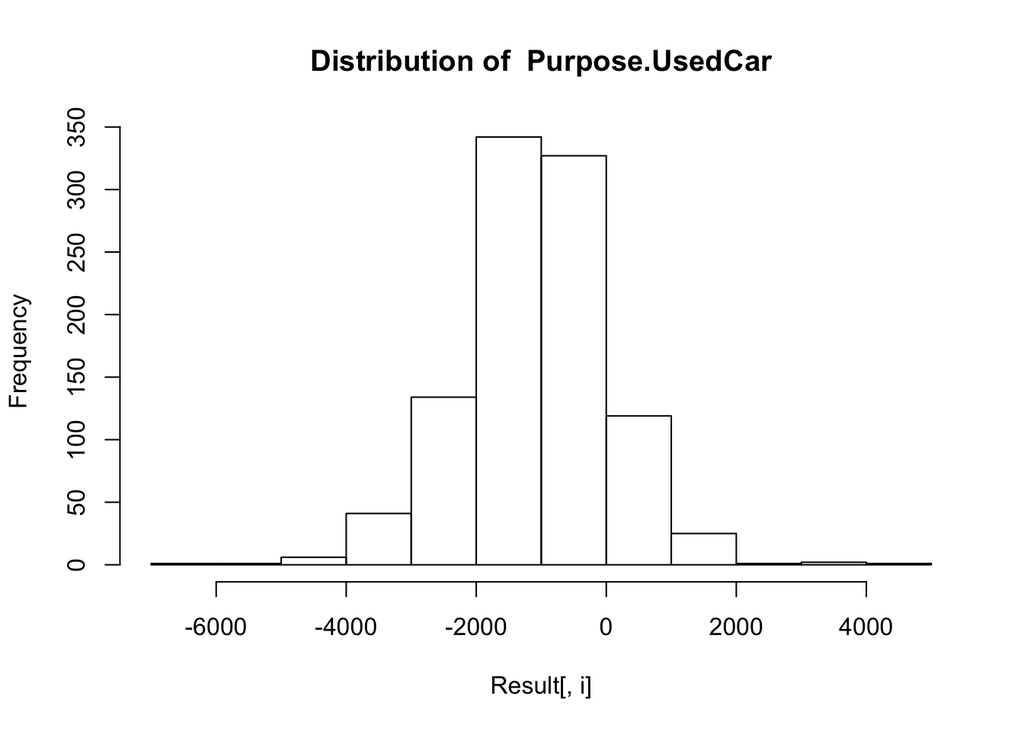

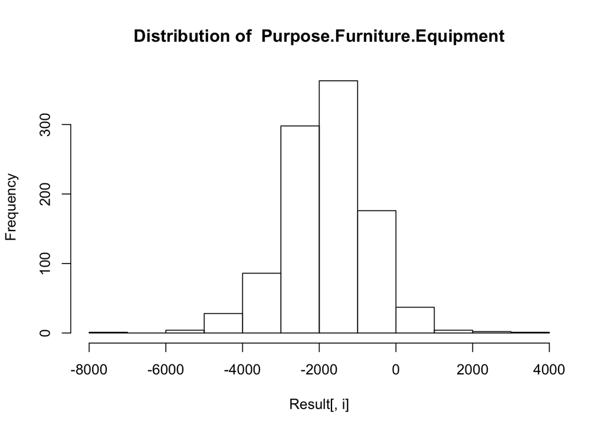

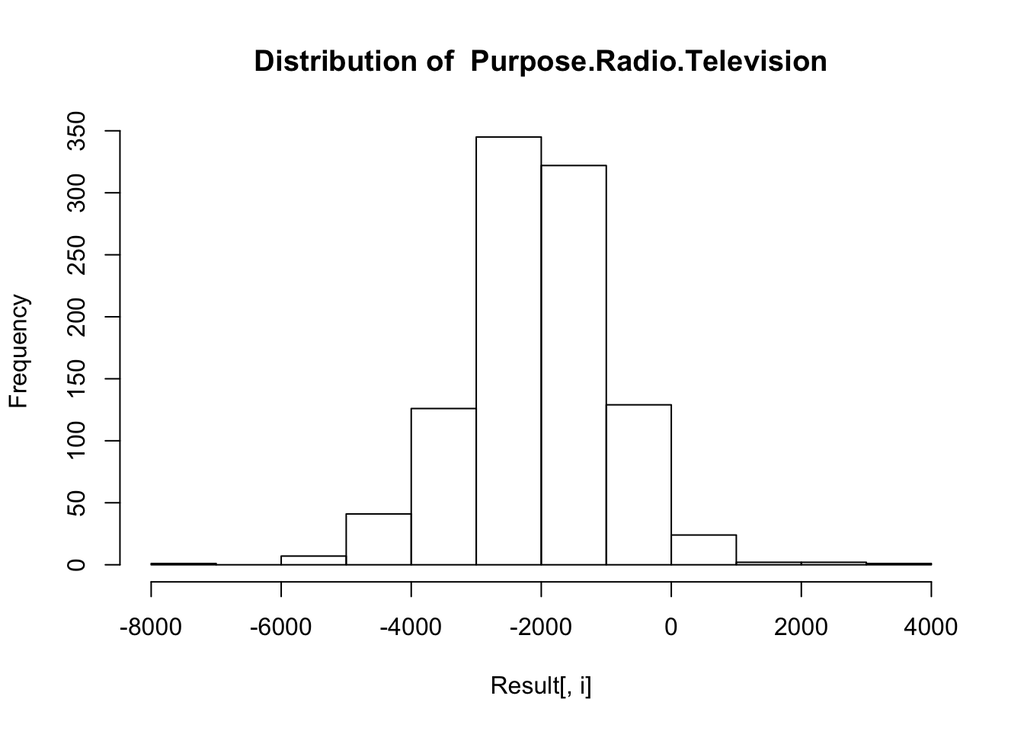

[20 more figures not shown]

```r
for(i in colnames(Result)){
  hist(Result[,i], main = paste("Distribution of ",i))
}
```

# • Compute the averages of all 1000 coefficients.

```r
df.avg.sd <- data.frame(Term = colnames(Result[1:29]),Average = colMeans(Result[,1:29]))
rownames(df.avg.sd)<- NULL
df.avg.sd
```

| Term | Average |
| --- | --- |
| Intercept | 7048.6655 |
| Duration | 124.8403 |
| InstallmentRatePercentage | -803.5292 |
| Telephone | -497.7123 |
| Class | -351.1621 |
| CheckingAccountStatus.lt.0 | -283.5907 |
| CheckingAccountStatus.gt.200 | -676.4645 |
| CreditHistory.NoCredit.AllPaid | 819.0528 |
| Purpose.NewCar | -1761.5069 |
| Purpose.UsedCar | -1094.2727 |

[output cut: 19 more lines]

# • Compute the standard deviation of all 1000 coefficients (for each beta)

```r
sd <- sapply(Result[,1:29], sd)
df.avg.sd$Standard.Deviation<-sd
rownames(df.avg.sd)<- NULL
df.avg.sd
```

| Term | Average | Standard.Deviation |
| --- | --- | --- |
| Intercept | 7048.6655 | 1154.57627 |
| Duration | 124.8403 | 5.40747 |
| InstallmentRatePercentage | -803.5292 | 46.17135 |
| Telephone | -497.7123 | 102.78526 |
| Class | -351.1621 | 128.98109 |
| CheckingAccountStatus.lt.0 | -283.5907 | 117.42381 |
| CheckingAccountStatus.gt.200 | -676.4645 | 130.41729 |
| CreditHistory.NoCredit.AllPaid | 819.0528 | 340.07547 |
| Purpose.NewCar | -1761.5069 | 1111.53277 |
| Purpose.UsedCar | -1094.2727 | 1123.85595 |

[output cut: 19 more lines]

# • Compare average across 1000 to single model built using entire sample.

Build model on entire data

```r
fit <- lm(Amount~., data = data)
df.avg.sd$Full_model <- fit$coefficients
df.avg.sd
```

| Term | Average | Standard.Deviation | Full_model |
| --- | --- | --- | --- |
| Intercept | 7048.6655 | 1154.57627 | 7026.7696 |
| Duration | 124.8403 | 5.40747 | 125.2081 |
| InstallmentRatePercentage | -803.5292 | 46.17135 | -802.7376 |
| Telephone | -497.7123 | 102.78526 | -499.8240 |
| Class | -351.1621 | 128.98109 | -353.3310 |
| CheckingAccountStatus.lt.0 | -283.5907 | 117.42381 | -285.1747 |
| CheckingAccountStatus.gt.200 | -676.4645 | 130.41729 | -672.2566 |
| CreditHistory.NoCredit.AllPaid | 819.0528 | 340.07547 | 829.4857 |
| Purpose.NewCar | -1761.5069 | 1111.53277 | -1741.6057 |
| Purpose.UsedCar | -1094.2727 | 1123.85595 | -1084.1573 |

[output cut: 19 more lines]

```r
mean(Result$R_Train)
```

```
## [1] 0.6142541
```

```r
summary(fit)$r.squared
```

```
## [1] 0.6058165
```

Average across 1000 sample coefficients somewhat approximately close to single model built using entire sample. Train R square is close to the entire sample r square.

# • Sort each coefficient’s 1000 values. Compute 2.5%-97.5% Confidence Intervals (CI). Scale these CI’s down by a factor of .632^0.5 .

## Sort the data

```r
sorted_result <- apply(Result,2, sort)
head(sorted_result)
```

```
##      Intercept Duration InstallmentRatePercentage Telephone     Class
## [1,]  1653.166 107.6427                 -933.6574 -804.3785 -755.8288
## [2,]  2758.716 108.7272                 -930.2526 -772.7397 -707.2837
## [3,]  3240.165 108.7889                 -925.4986 -769.7681 -700.1587
## [4,]  3293.193 109.7842                 -917.8504 -768.5702 -691.2755
## [5,]  3487.585 110.9111                 -915.4622 -766.8386 -685.5386
## [6,]  3779.085 111.0229                 -914.7136 -763.3426 -670.8504
##      CheckingAccountStatus.lt.0 CheckingAccountStatus.gt.200
## [1,]                  -667.1950                    -1067.666
## [2,]                  -656.1917                    -1031.722
## [3,]                  -628.8398                    -1030.458
## [4,]                  -608.1073                    -1022.893
## [5,]                  -590.8198                    -1021.299
## [6,]                  -584.0670                    -1009.820
##      CreditHistory.NoCredit.AllPaid Purpose.NewCar Purpose.UsedCar
```

[output cut: 69 more lines]

## Calculate 2.5%-97.5% confidence interval

```r
lower_ci <- sapply(Result[,1:29], function(a){
  mean(a) - qnorm(0.975)*sd(a)/sqrt(1000)
})


upper_ci <- sapply(Result[,1:29], function(a){
  mean(a) + qnorm(0.975)*sd(a)/sqrt(1000)
})
print("2.5%-97.5% confidence interval")
```

```
## [1] "2.5%-97.5% confidence interval"
```

```r
ci <- data.frame(Term = colnames(Result)[1:29],"lower 2.5%"= lower_ci,"upper 97.5%"= upper_ci)
rownames(ci)<- NULL
# scale the CI
ci
```

| Term | lower.2.5. | upper.97.5. |
| --- | --- | --- |
| Intercept | 6977.1054 | 7120.2256 |
| Duration | 124.5052 | 125.1755 |
| InstallmentRatePercentage | -806.3909 | -800.6675 |
| Telephone | -504.0828 | -491.3417 |
| Class | -359.1563 | -343.1679 |
| CheckingAccountStatus.lt.0 | -290.8686 | -276.3128 |
| CheckingAccountStatus.gt.200 | -684.5477 | -668.3813 |
| CreditHistory.NoCredit.AllPaid | 797.9751 | 840.1305 |
| Purpose.NewCar | -1830.3991 | -1692.6146 |
| Purpose.UsedCar | -1163.9287 | -1024.6166 |

[output cut: 19 more lines]

```r
ci[,2:3] <- ci[,2:3]*(0.632^0.5)
print("Confidence Interval Scaled")
```

```
## [1] "Confidence Interval Scaled"
```

```r
ci
```

| Term | lower.2.5. | upper.97.5. |
| --- | --- | --- |
| Intercept | 5546.68911 | 5660.46737 |
| Duration | 98.97965 | 99.51253 |
| InstallmentRatePercentage | -641.06805 | -636.51808 |
| Telephone | -400.73793 | -390.60891 |
| Class | -285.52359 | -272.81309 |
| CheckingAccountStatus.lt.0 | -231.23593 | -219.66434 |
| CheckingAccountStatus.gt.200 | -544.20469 | -531.35266 |
| CreditHistory.NoCredit.AllPaid | 634.37766 | 667.89055 |
| Purpose.NewCar | -1455.13852 | -1345.60202 |
| Purpose.UsedCar | -925.30501 | -814.55411 |

[output cut: 19 more lines]

```r
print("Single full model CI")
```

```
## [1] "Single full model CI"
```

```r
confint(fit)
```

```
##                                          2.5 %      97.5 %
## (Intercept)                         5803.58724 8249.951869
## Duration                             114.73619  135.680095
## InstallmentRatePercentage           -907.67378 -697.801413
## Telephone                           -756.73499 -242.912979
## ClassGood                           -625.42680  -81.235262
## CheckingAccountStatus.lt.0          -560.86038   -9.488975
## CheckingAccountStatus.gt.200       -1143.31044 -201.202787
## CreditHistory.NoCredit.AllPaid       235.19487 1423.776454
## Purpose.NewCar                     -2828.29703 -654.914413
## Purpose.UsedCar                    -2191.30159   22.986936
## Purpose.Furniture.Equipment        -2881.59508 -685.888865
## Purpose.Radio.Television           -3122.73763 -942.524201
## Purpose.DomesticAppliance          -3879.41510 -897.923124
## Purpose.Repairs                    -2974.12577 -353.411953
## Purpose.Education                  -3067.96844 -705.935812
## Purpose.Retraining                 -3812.34708 -598.708080
## Purpose.Business                   -3044.49769 -809.364713
## SavingsAccountBonds.lt.100          -575.96621    1.165596
## SavingsAccountBonds.100.to.500      -945.53363  -89.503887
## SavingsAccountBonds.500.to.1000    -1130.32068 -115.982230
## EmploymentDuration.gt.7             -489.36764   52.129975
## Personal.Male.Single                 251.22561  724.701134
## OtherDebtorsGuarantors.CoApplicant    39.65711 1197.078236
## Property.RealEstate                -1104.65760 -297.335228
## Property.Insurance                  -838.28281  -51.274726
## Property.CarOther                   -808.26802  -80.111262
## Job.UnemployedUnskilled            -2528.98004 -838.453331
## Job.UnskilledResident              -1691.97405 -798.404704
## Job.SkilledEmployee                -1649.85593 -931.881578
```

These CIs are tighter than single model CIs. # • Summarize results.

1. Using step-wise regression model I’ve first selected 28 predictor variables.
2. After that I did train test split and calculated all coefficients, holdout R2 and % fall in R2.
3. From the coefficients histogram it was found that all the coefficients value satisfy the assumption of central limit theorem.
4. Confidence interval of training and test data set were narrower than single sample confidence interval.